# CDS scRNA-seq Workshop 2022 Section 2 - Standard Pipeline

Stephanie The

2022-04-06

# Packages

**If you are starting a new session, you will need to reload the packages and run the code below:**

```r
library(tidyverse)
library(Seurat)
library(pheatmap)
library(RColorBrewer)
library(scales)
library(cowplot)
library(patchwork)
library(grid)
library(gridExtra)
library(harmony)
library(clusterProfiler)
library(org.Hs.eg.db)
library(ReactomePA)
library(msigdbr)
```

```r
# set seed
set.seed(1383)

# set working directory
setwd('D:/scRNA-seq pipeline/pasca_dataset/')

# import metadata
metadata <- read_csv('data/metadata.csv')
# load raw objects
obs <- readRDS('pasca_raw_objects.rds')
```

# QC

QC is very important because you need to filter out low-quality cells, such as:

- dead cells
- empty cells
- doublets/multiplets

Remember we all ready did some filtering when creating objects for each sample. This is with *min.cells* and *min.features*.

```
CreateSeuratObject(counts, project = 'pasca', min.cells = 3, min.features = 100)
```

For this main QC part, we will be filtering cells based on these 4 variables:

- **nCount** (nCount_RNA) = # of transcripts per cell
- **nFeature** (nFeature_RNA) = # of genes detected per cell
- **percent.mt** = % mitochondrial genes detected per cell
- **percent.rb** = % ribosomal genes detected per cell

## Calculate mitocondrial and ribosomal reads

Before we filter, we need to calculate *percent.mt* and *percent.rb* variables. We can either find these genes with a regex pattern or put in a gene list.

Gene names between human and mouse are different.

For human:

- mitochondrial genes = ‘^MT-’
- ribosomal genes = ‘^RP[SL]’

For mouse:

- mitochondrial genes = ‘^mt-’
- ribosomal genes = ‘^Rp[sl]’

```r
# calculate percentage of a gene set
# ?PercentageFeatureSet

# with regex pattern
head(PercentageFeatureSet(object = obs[[1]], pattern = '^MT-'))
```

```
##                     nCount_RNA
## AAACCCAGTCCAGCCA-1 76.76767677
## AAACCCAGTCCGACGT-1 10.86453999
## AAACCCAGTGTCGCTG-1  0.14560280
## AAACCCATCTGCACCT-1  0.15873016
## AAACGAAAGCGACCCT-1  0.02484935
## AAACGAAAGCGGACAT-1  6.86674670
```

```r
# with gene list
gene_list <- rownames(obs[[1]])[grep('^MT-',rownames(obs[[1]]))]
head(PercentageFeatureSet(object = obs[[1]], features = gene_list))
```

```
##                     nCount_RNA
## AAACCCAGTCCAGCCA-1 76.76767677
## AAACCCAGTCCGACGT-1 10.86453999
## AAACCCAGTGTCGCTG-1  0.14560280
## AAACCCATCTGCACCT-1  0.15873016
## AAACGAAAGCGACCCT-1  0.02484935
## AAACGAAAGCGGACAT-1  6.86674670
```

Let’s now calculate *percent.mt* and *percent.rb* for every sample object. These variables will then be stored in the metadata slot in each object.

```r
# calculate mitochondria and ribosomal reads for each cell in each object
for (i in 1:length(obs)) {
  obs[[i]]$percent.mt <- PercentageFeatureSet(obs[[i]], pattern = "^MT-")
  obs[[i]]$percent.rb <- PercentageFeatureSet(obs[[i]], pattern = '^RP[SL]')
}

# percentages for mt and rb are stored in metadata slot for each object
head(obs[[1]]@meta.data)
```

```
##                    orig.ident nCount_RNA nFeature_RNA        sample_id
## AAACCCAGTCCAGCCA-1      pasca        891          179 AdjNorm_TISSUE_1
## AAACCCAGTCCGACGT-1      pasca       2163         1003 AdjNorm_TISSUE_1
## AAACCCAGTGTCGCTG-1      pasca       6868          156 AdjNorm_TISSUE_1
## AAACCCATCTGCACCT-1      pasca        630          360 AdjNorm_TISSUE_1
## AAACGAAAGCGACCCT-1      pasca      16097          827 AdjNorm_TISSUE_1
## AAACGAAAGCGGACAT-1      pasca       4165         1527 AdjNorm_TISSUE_1
##                    condition  percent.mt percent.rb
## AAACCCAGTCCAGCCA-1         N 76.76767677  5.1627385
## AAACCCAGTCCGACGT-1         N 10.86453999 14.0545539
## AAACCCAGTGTCGCTG-1         N  0.14560280  0.3057659
## AAACCCATCTGCACCT-1         N  0.15873016 28.7301587
## AAACGAAAGCGACCCT-1         N  0.02484935  5.8147481
## AAACGAAAGCGGACAT-1         N  6.86674670 21.0804322
```

## One Sample QC

Now we can do QC and filtering. To make it simple at first, let’s do it on one sample. We will be using the *AdjNorm_TISSUE_1* sample for this example. This is *obs[[1]]* in our list of objects.

### Before Filtering

The first step is to look at violin and scatter plots of the 4 QC variables.

- violin plot = looking at variables individually

```r
# ?VlnPlot
```

- scatter plot = looking at combination of 2 variables

```r
# ?FeaturePlot
```

Remember, we want to get the cells that represent the majority of the distribution.

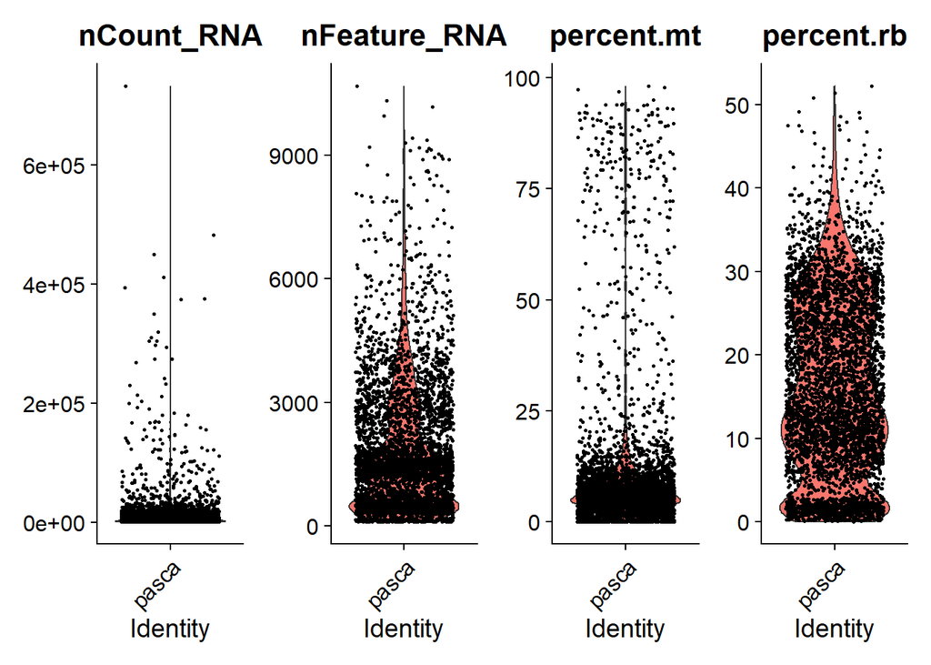

```r
# plot violin plot of QC variables AdjNorm_TISSUE_1 sample QC
VlnPlot(obs[[1]], features = c("nCount_RNA","nFeature_RNA", "percent.mt", "percent.rb"), ncol = 4, pt.size = .5)
```

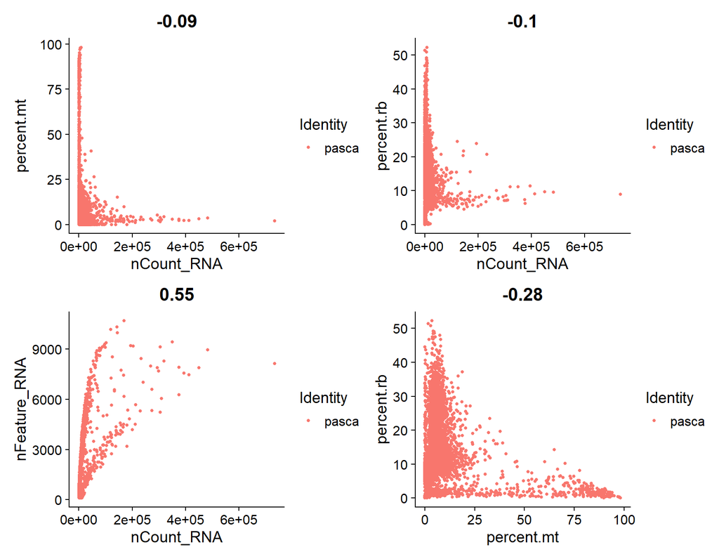

```r
# plot feature scatter plot of QC variables for AdjNorm_TISSUE_1 sample QC
plot1 <- FeatureScatter(object = obs[[1]], feature1 = "nCount_RNA", feature2 = "percent.mt")
plot2 <- FeatureScatter(object = obs[[1]], feature1 = "nCount_RNA", feature2 = "percent.rb")
plot3 <- FeatureScatter(object = obs[[1]], feature1 = "nCount_RNA", feature2 = "nFeature_RNA")
plot4 <- FeatureScatter(object = obs[[1]], feature1 = "percent.mt", feature2 = "percent.rb")
wrap_plots(plot1, plot2, plot3, plot4, ncol = 2, nrow = 2)
```

I normally save the QC plots for transparency, and they can be included in articles if needed. Here is an example of how to save plots (either png or pdf):

```r
# how to save plots
## DO NOT RUN

## png file
# png(filename = 'vlnplot.png', width = 500, height = 500)
# print(VlnPlot(obs[[1]], features = c("nCount_RNA","nFeature_RNA", "percent.mt", "percent.rb"), ncol = 4, pt.size = .5))
# dev.off()

## pdf file
# pdf(file = 'vlnplot.pdf', width = 5, height = 5)
# print(VlnPlot(obs[[1]], features = c("nCount_RNA","nFeature_RNA", "percent.mt", "percent.rb"), ncol = 4, pt.size = .5))
# dev.off()
```

### Picking Thresholds

The second step is to pick the thresholds for all 4 QC variables. There will be a low threshold and high threshold. The cells in the range of these thresholds will be kept, and cells outside will be filtered out. **For the high threshold, overestimating it is fine.** You don’t want to filter out too many cells.

```r
# get range of QC variables AdjNorm_TISSUE_1 sample QC
## this will give you the min and max of the current variables
nCount_RNA_range <- range(obs[[1]]$nCount_RNA)
nFeature_RNA_range <- range(obs[[1]]$nFeature_RNA)
percent.mt_range <- range(obs[[1]]$percent.mt)
percent.rb_range <- range(obs[[1]]$percent.rb)

nCount_RNA_range
```

```
## [1]    500 733526
```

```r
# fill in list of filtering thresholds for each QC variable
## each vector in list should contain 2 values (low threshold, high threshold)
vln_y_line <- list(
  nCount_RNA = c(nCount_RNA_range[1],3e5),
  nFeature_RNA = c(nFeature_RNA_range[1], 8000),
  percent.mt = c(percent.mt_range[1],20),
  percent.rb = c(percent.rb_range[1],percent.rb_range[2])
)

vln_y_line
```

```
## $nCount_RNA
## [1] 5e+02 3e+05
##
## $nFeature_RNA
## [1]  100 8000
##
## $percent.mt
## [1]  0 20
##
## $percent.rb
## [1]  0.0000 52.2488
```

The third step is to check that the thresholds look good with plots. We will add threshold lines to show where we am filtering. I do this step to make sure I didn’t mistype any values or if I want to change the threshold before actually filtering.

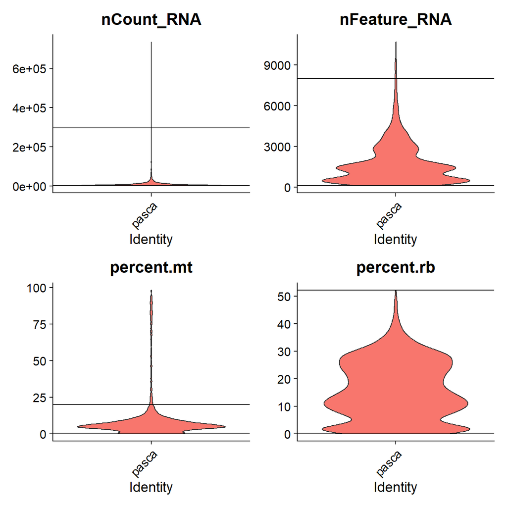

```r
# violin plots with threshold lines
plot1 <- VlnPlot(obs[[1]], features = c("nCount_RNA"), pt.size = 0) & geom_hline(yintercept = c(vln_y_line[[1]][1], vln_y_line[[1]][2])) & theme(legend.position = 'none')
plot2 <- VlnPlot(obs[[1]], features = c("nFeature_RNA"), pt.size = 0) & geom_hline(yintercept = c(vln_y_line[[2]][1], vln_y_line[[2]][2])) & theme(legend.position = 'none')
plot3 <- VlnPlot(obs[[1]], features = c("percent.mt"), pt.size = 0) & geom_hline(yintercept = c(vln_y_line[[3]][1], vln_y_line[[3]][2])) & theme(legend.position = 'none')
plot4 <- VlnPlot(obs[[1]], features = c("percent.rb"), pt.size = 0) & geom_hline(yintercept = c(vln_y_line[[4]][1], vln_y_line[[4]][2])) & theme(legend.position = 'none')

wrap_plots(plot1, plot2, plot3, plot4, ncol = 2, nrow = 2)
```

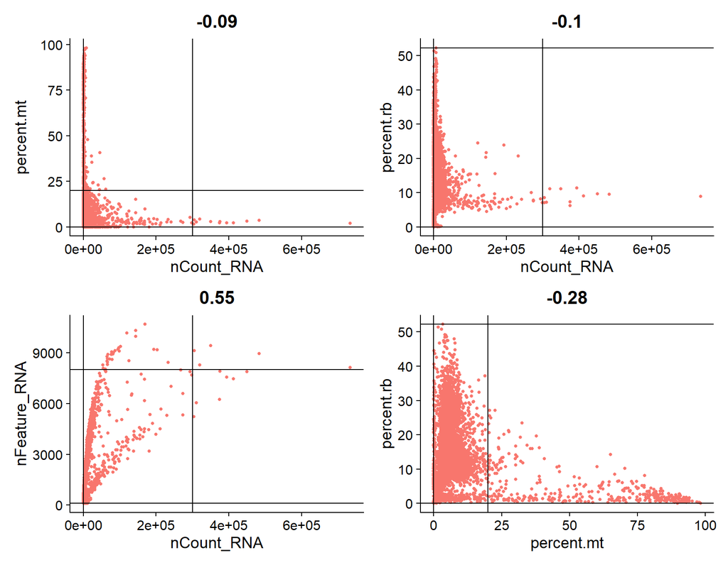

```r
# feature scatter plots with threshold lines
plot1 <- FeatureScatter(object = obs[[1]], feature1 = "nCount_RNA", feature2 = "percent.mt") + geom_hline(yintercept = c(vln_y_line[[3]][1], vln_y_line[[3]][2])) + geom_vline(xintercept = c(vln_y_line[[1]][1], vln_y_line[[1]][2])) + theme(legend.position = 'none')
plot2 <- FeatureScatter(object = obs[[1]], feature1 = "nCount_RNA", feature2 = "percent.rb") & geom_hline(yintercept = c(vln_y_line[[4]][1], vln_y_line[[4]][2])) & geom_vline(xintercept = c(vln_y_line[[1]][1], vln_y_line[[1]][2])) & theme(legend.position = 'none')
plot3 <- FeatureScatter(object = obs[[1]], feature1 = "nCount_RNA", feature2 = "nFeature_RNA") & geom_hline(yintercept = c(vln_y_line[[2]][1], vln_y_line[[2]][2])) & geom_vline(xintercept = c(vln_y_line[[1]][1], vln_y_line[[1]][2])) & theme(legend.position = 'none')
plot4 <- FeatureScatter(object = obs[[1]], feature1 = "percent.mt", feature2 = "percent.rb") & geom_hline(yintercept = c(vln_y_line[[4]][1], vln_y_line[[4]][2])) & geom_vline(xintercept = c(vln_y_line[[3]][1], vln_y_line[[3]][2])) & theme(legend.position = 'none')

plot1 + plot2 + plot3 + plot4
```

### Filtering

The fourth step is to actually filter with the thresholds we have chosen. We will be using this function:

```r
# ?subset

obs[[1]] <- subset(obs[[1]], subset =
                     (nCount_RNA >= vln_y_line[[1]][1] &
                        nCount_RNA <= vln_y_line[[1]][2]) &
                     (nFeature_RNA >= vln_y_line[[2]][1] &
                        nFeature_RNA <= vln_y_line[[2]][2]) &
                     (percent.mt >= vln_y_line[[3]][1] &
                        percent.mt <= vln_y_line[[3]][2]) &
                     (percent.rb >= vln_y_line[[4]][1] &
                        percent.rb <= vln_y_line[[4]][2])
              )
```

You don’t actually have to specify all the thresholds when filtering/subsetting. In this sample, we only filtered on *nCount*, *nFeature*, and *percent.mt*, so we don’t have to include *percent.rb* in the function. Also, we didn’t set any new low thresholds, so we don’t have to specify those thresholds either.

The code will look like this:

```r
## DO NOT RUN
# obs[[1]] <- subset(obs[[1]], subset = nCount_RNA <= 3e5 & nFeature_RNA <= 8000 & percent.mt <= 20)
```

I have only included all the thresholds (low and high) for automated processing reasons. You will see this later on in the script when we filter all sample objects at once.

### After Filtering

The fifth step is to check that filtering worked and it looks good with plots. If you did mess up, you can go back to the raw objects by reloading the “pasca_raw_objects.rds” file.

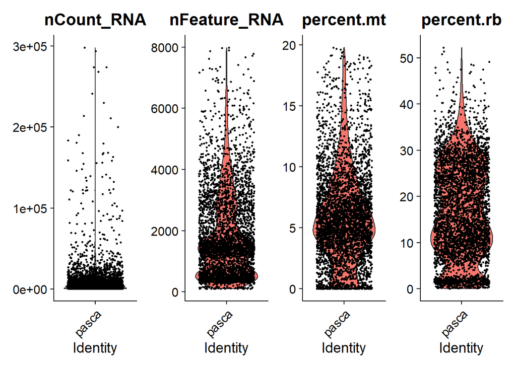

```r
VlnPlot(obs[[1]], features = c("nCount_RNA", "nFeature_RNA", "percent.mt", "percent.rb"), ncol = 4, pt.size = .5)
```

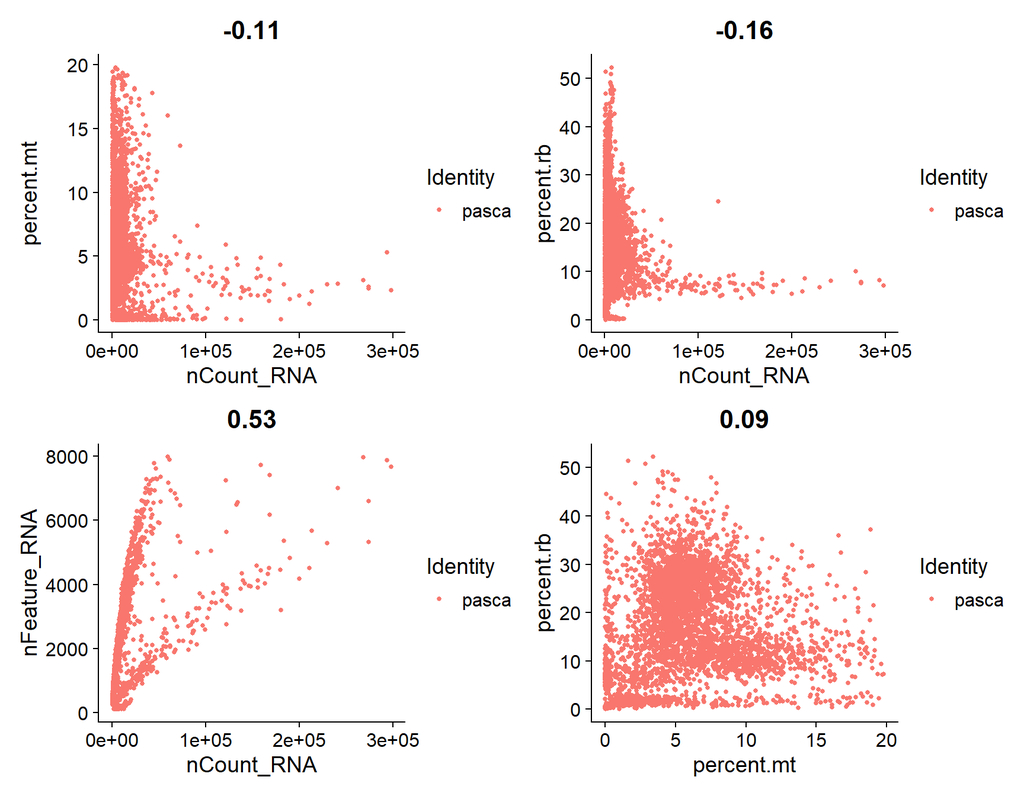

```r
plot1 <- FeatureScatter(object = obs[[1]], feature1 = "nCount_RNA", feature2 = "percent.mt")
plot2 <- FeatureScatter(object = obs[[1]], feature1 = "nCount_RNA", feature2 = "percent.rb")
plot3 <- FeatureScatter(object = obs[[1]], feature1 = "nCount_RNA", feature2 = "nFeature_RNA")
plot4 <- FeatureScatter(object = obs[[1]], feature1 = "percent.mt", feature2 = "percent.rb")
wrap_plots(plot1, plot2, plot3, plot4, ncol = 2, nrow = 2)
```

## All Samples QC

We will now filter all the samples at once. This code is specialized to filter on each sample object to make it automated. This helps with making the code clean by reducing duplicated code. The difference for this specialized code for all samples is that the main functions are wrapped around in loops. Also, it automatically saves plots as png files outside of R.

We will reload the raw objects, but we will keep the thresholds we found above for the first sample.

```r
# load raw objects again
obs <- readRDS('D:/scRNA-seq pipeline/pasca_dataset/pasca_raw_objects.rds')
```

### Calculate mitocondrial and ribosomal reads

```r
# calculate mitochondria and ribosomal reads for each cell in each object
for (i in 1:length(obs)) {
  obs[[i]]$percent.mt <- PercentageFeatureSet(obs[[i]], pattern = "^MT-")
  obs[[i]]$percent.rb <- PercentageFeatureSet(obs[[i]], pattern = '^RP[SL]')
}
```

### Before Filtering

```r
# export no line plots
# DO NOT RUN
# for (i in 1:length(obs)) {
#   # vlnplot (no lines)
#   file_name_1 <- paste0('plots/qc/qc_vln_before_',metadata$sample_id[i],'.png')
#   png(filename = file_name_1, width = 500, height = 500)
#   print(VlnPlot(obs[[i]], features = c("nCount_RNA", "nFeature_RNA", "percent.mt", "percent.rb"), ncol = 4, pt.size = .5))
#   dev.off()
#
#   # feature scatter (no lines)
#   file_name_2 <- paste0('plots/qc/qc_featurescatter_before_',metadata$sample_id[i],'.png')
#   plot1 <- FeatureScatter(object = obs[[i]], feature1 = "nCount_RNA", feature2 = "percent.mt")
#   plot2 <- FeatureScatter(object = obs[[i]], feature1 = "nCount_RNA", feature2 = "percent.rb")
#   plot3 <- FeatureScatter(object = obs[[i]], feature1 = "nCount_RNA", feature2 = "nFeature_RNA")
#   plot4 <- FeatureScatter(object = obs[[i]], feature1 = "percent.mt", feature2 = "percent.rb")
#   png(filename = file_name_2, width = 800, height = 800)
#   print(wrap_plots(plot1, plot2, plot3, plot4, ncol = 2, nrow = 2))
#   dev.off()
#
# }
```

### Exercise: Picking Thresholds

Choose the thresholds for the other 5 samples:

- AdjNorm_TISSUE_2
- AdjNorm_TISSUE_3
- PDAC_TISSUE_1
- PDAC_TISSUE_2
- PDAC_TISSUE_3

We already did *AdjNorm_TISSUE_1* together, so don’t change those values!

Make sure you include a low and high threshold in every vector for each variable for each sample (otherwise you’ll get an error). Since we aren’t setting a low threshold, please don’t change the first element of each vector. Also, don’t worry about filtering on *percent.rb*. Please don’t change those values in any sample.

ex: nCount_RNA = c(nCount_RNA_range[[1]][1],{high threshold})

**The elements/values you can change will have {val} as a placeholder.**

You can check your thresholds with the plots. You will have to run the whole for loop to save and see the plots outside of R.

```r
# get range of QC variables for each sample object
## this will give you the min and max of the current variables
nCount_RNA_range <- sapply(obs, function(x) list(range(x$nCount_RNA)))
nFeature_RNA_range <- sapply(obs, function(x) list(range(x$nFeature_RNA)))
percent.mt_range <- sapply(obs, function(x) list(range(x$percent.mt)))
percent.rb_range <- sapply(obs, function(x) list(range(x$percent.rb)))
```

```r
vln_y_line <- list(

  # AdjNorm_TISSUE_1
  list(nCount_RNA = c(nCount_RNA_range[[1]][1],3e5),
       nFeature_RNA = c(nFeature_RNA_range[[1]][1], 8000),
       percent.mt = c(percent.mt_range[[1]][1],20),
       percent.rb = c(percent.rb_range[[1]][1],percent.rb_range[[1]][2])),

  # AdjNorm_TISSUE_2
  list(nCount_RNA = c(nCount_RNA_range[[2]][1],'{val}'),
       nFeature_RNA = c(nFeature_RNA_range[[2]][1], '{val}'),
       percent.mt = c(percent.mt_range[[2]][1],'{val}'),
       percent.rb = c(percent.rb_range[[2]][1],percent.rb_range[[2]][2])),

  # AdjNorm_TISSUE_3
  list(nCount_RNA = c(nCount_RNA_range[[3]][1],'{val}'),
       nFeature_RNA = c(nFeature_RNA_range[[3]][1], '{val}'),
       percent.mt = c(percent.mt_range[[3]][1],'{val}'),
       percent.rb = c(percent.rb_range[[3]][1],percent.rb_range[[3]][2])),

  # PDAC_TISSUE_1
  list(nCount_RNA = c(nCount_RNA_range[[4]][1],'{val}'),
       nFeature_RNA = c(nFeature_RNA_range[[4]][1], '{val}'),
       percent.mt = c(percent.mt_range[[4]][1],'{val}'),
       percent.rb = c(percent.rb_range[[4]][1],percent.rb_range[[4]][2])),

  # PDAC_TISSUE_2
  list(nCount_RNA = c(nCount_RNA_range[[5]][1],'{val}'),
       nFeature_RNA = c(nFeature_RNA_range[[5]][1], '{val}'),
       percent.mt = c(percent.mt_range[[5]][1],'{val}'),
       percent.rb = c(percent.rb_range[[5]][1],percent.rb_range[[5]][2])),

  # PDAC_TISSUE_3
  list(nCount_RNA = c(nCount_RNA_range[[6]][1],'{val}'),
       nFeature_RNA = c(nFeature_RNA_range[[6]][1],'{val}'),
       percent.mt = c(percent.mt_range[[6]][1],'{val}'),
       percent.rb = c(percent.rb_range[[6]][1],percent.rb_range[[6]][2]))
)
```

```r
# exporting line plots
# DO NOT RUN
# for (i in 1:length(obs)) {
#   # vlnplot (lines)
#   file_name_1 <- paste0('plots/qc/qc_vln_before_line_',metadata$sample_id[i],'.png')
#   plot1 <- VlnPlot(obs[[i]], features = c("nCount_RNA"), pt.size = 0) & geom_hline(yintercept = c(vln_y_line[[i]][[1]][1], vln_y_line[[i]][[1]][2])) & theme(legend.position = 'none')
#   plot2 <- VlnPlot(obs[[i]], features = c("nFeature_RNA"), pt.size = 0) & geom_hline(yintercept = c(vln_y_line[[i]][[2]][1], vln_y_line[[i]][[2]][2])) & theme(legend.position = 'none')
#   plot3 <- VlnPlot(obs[[i]], features = c("percent.mt"), pt.size = 0) & geom_hline(yintercept = c(vln_y_line[[i]][[3]][1], vln_y_line[[i]][[3]][2])) & theme(legend.position = 'none')
#   plot4 <- VlnPlot(obs[[i]], features = c("percent.rb"), pt.size = 0) & geom_hline(yintercept = c(vln_y_line[[i]][[4]][1], vln_y_line[[i]][[4]][2])) & theme(legend.position = 'none')
#
#   png(filename = file_name_1, width = 500, height = 500)
#   print(wrap_plots(plot1, plot2, plot3, plot4, ncol = 2, nrow = 2))
#   dev.off()
#
#   # feature scatter (lines)
#   file_name_2 <- paste0('plots/qc/qc_featurescatter_before_line_',metadata$sample_id[i],'.png')
#   plot1 <- FeatureScatter(object = obs[[i]], feature1 = "nCount_RNA", feature2 = "percent.mt") + geom_hline(yintercept = c(vln_y_line[[i]][[3]][1], vln_y_line[[i]][[3]][2])) + geom_vline(xintercept = c(vln_y_line[[i]][[1]][1], vln_y_line[[i]][[1]][2])) + theme(legend.position = 'none')
#   plot2 <- FeatureScatter(object = obs[[i]], feature1 = "nCount_RNA", feature2 = "percent.rb") & geom_hline(yintercept = c(vln_y_line[[i]][[4]][1], vln_y_line[[i]][[4]][2])) & geom_vline(xintercept = c(vln_y_line[[i]][[1]][1], vln_y_line[[i]][[1]][2])) & theme(legend.position = 'none')
#   plot3 <- FeatureScatter(object = obs[[i]], feature1 = "nCount_RNA", feature2 = "nFeature_RNA") & geom_hline(yintercept = c(vln_y_line[[i]][[2]][1], vln_y_line[[i]][[2]][2])) & geom_vline(xintercept = c(vln_y_line[[i]][[1]][1], vln_y_line[[i]][[1]][2])) & theme(legend.position = 'none')
#   plot4 <- FeatureScatter(object = obs[[i]], feature1 = "percent.mt", feature2 = "percent.rb") & geom_hline(yintercept = c(vln_y_line[[i]][[4]][1], vln_y_line[[i]][[4]][2])) & geom_vline(xintercept = c(vln_y_line[[i]][[3]][1], vln_y_line[[i]][[3]][2])) & theme(legend.position = 'none')
#
#   png(filename = file_name_2, width = 800, height = 800)
#   print(plot1 + plot2 + plot3 + plot4)
#   dev.off()
# }
```

### Filtering

```r
for (i in 1:length(obs)) {
  obs[[i]] <- subset(obs[[i]], subset = (nCount_RNA >= vln_y_line[[i]][[1]][1] & nCount_RNA <= vln_y_line[[i]][[1]][2]) & (nFeature_RNA >= vln_y_line[[i]][[2]][1] & nFeature_RNA <= vln_y_line[[i]][[2]][2]) & (percent.mt >= vln_y_line[[i]][[3]][1] & percent.mt <= vln_y_line[[i]][[3]][2]) & (percent.rb >= vln_y_line[[i]][[4]][1] & percent.rb <= vln_y_line[[i]][[4]][2]))
}
```

### After Filtering

```r
# export no line plots
# DO NOT RUN
# for (i in 1:length(obs)) {
#   # vlnplot (no lines)
#   file_name_1 <- paste0('plots/qc/qc_vln_after_',metadata$sample_id[i],'.png')
#   png(filename = file_name_1, width = 500, height = 500)
#   print(VlnPlot(obs[[i]], features = c("nCount_RNA", "nFeature_RNA", "percent.mt", "percent.rb"), ncol = 4, pt.size = .5))
#   dev.off()
#
#   # feature scatter (no lines)
#   file_name_2 <- paste0('plots/qc/qc_featurescatter_after_',metadata$sample_id[i],'.png')
#   plot1 <- FeatureScatter(object = obs[[i]], feature1 = "nCount_RNA", feature2 = "percent.mt")
#   plot2 <- FeatureScatter(object = obs[[i]], feature1 = "nCount_RNA", feature2 = "percent.rb")
#   plot3 <- FeatureScatter(object = obs[[i]], feature1 = "nCount_RNA", feature2 = "nFeature_RNA")
#   plot4 <- FeatureScatter(object = obs[[i]], feature1 = "percent.mt", feature2 = "percent.rb")
#   png(filename = file_name_2, width = 800, height = 800)
#   print(wrap_plots(plot1, plot2, plot3, plot4, ncol = 2, nrow = 2))
#   dev.off()
#
# }
```

## Look at number of cells after QC filtering

We can check the new # of cells in each sample object with the code below. This is a good sanity check to make sure filtering went well.

```r
cat('Total # of cells per object/sample \n\n')
```

```
## Total # of cells per object/sample
```

```r
unlist(sapply(obs, function(x) ncol(x)))
```

```
## AdjNorm_TISSUE_1 AdjNorm_TISSUE_2 AdjNorm_TISSUE_3    PDAC_TISSUE_1
##             4130             2864              874             1389
##    PDAC_TISSUE_2    PDAC_TISSUE_3
##             1740             2085
```

# Unbatched Analysis

Before considering integration, I like to analyze my dataset ignoring batch effect first even if I know that it has a batch effect. I mainly do this so I can for sure check to make sure what my batch variable(s) is. It also allows for transparency that serves as proof that you have a batch effect and that it was corrected for in the main figures in your articles.

## Merge objects

Since our objects are separated by sample, we will have to merge the objects together before we can do the rest of the standard pipeline. We will go over the integration pipeline later on.

```r
# long format
## DO NOT RUN
# merged_ob <- merge(x = obs[[1]], y = c(obs[[2]], obs[[3]], obs[[4]], obs[[5]], obs[[6]]), add.cell.ids = metadata$sample_id)

# short, cleaner format
## need to include add.cell.ids (adds sample name to barcode name)
more_obs <- paste0("c(",paste(sapply(2:length(obs),function(i) paste0("obs[[",i,"]]")),collapse=",",sep=""),")")
merged_ob <- merge(obs[[1]], eval(parse(text=more_obs)), add.cell.ids = metadata$sample_id)

# cell names before merge
head(colnames(obs[[1]]))
```

```
## [1] "AAACCCAGTCCGACGT-1" "AAACCCAGTGTCGCTG-1" "AAACCCATCTGCACCT-1"
## [4] "AAACGAAAGCGACCCT-1" "AAACGAAAGCGGACAT-1" "AAACGAAAGTCACACT-1"
```

```r
# cell names after merge
head(colnames(merged_ob))
```

```
## [1] "AdjNorm_TISSUE_1_AAACCCAGTCCGACGT-1" "AdjNorm_TISSUE_1_AAACCCAGTGTCGCTG-1"
## [3] "AdjNorm_TISSUE_1_AAACCCATCTGCACCT-1" "AdjNorm_TISSUE_1_AAACGAAAGCGACCCT-1"
## [5] "AdjNorm_TISSUE_1_AAACGAAAGCGGACAT-1" "AdjNorm_TISSUE_1_AAACGAAAGTCACACT-1"
```

```r
# remove separated sample objects (don't need them anymore)
rm(obs)
gc()
```

```
##            used  (Mb) gc trigger   (Mb)  max used   (Mb)
## Ncells  6423015 343.1    9740197  520.2   9740197  520.2
## Vcells 94679259 722.4  292886550 2234.6 265427516 2025.1
```

## Normalization

Normalization transforms the distribution of the data, which, in this scRNA-seq analysis, it transform the data into a more normal distribution. Normalization helps to reduce unwanted variation, compare among samples better, and make the values easier to see (can see differences better).

We will use this function:

```r
# run normalization
# ?NormalizeData
merged_ob <- NormalizeData(merged_ob)
```

## Find Variable Features

We have over 10,000 genes in this dataset. We want to find the genes that will give us the most information without using all of the genes. These genes will have the most variance (aka the most variable).

We will use this function to find the most variable genes:

```r
# find most variable genes
# ?FindVariableFeatures
merged_ob <- FindVariableFeatures(merged_ob)
```

We will choose the top 2000 genes for this example. You can change the # of variable genes, and this will change the results. When choosing the # of variable genes, overestimating is usually better than underestimating.

We can look at our variable genes with this function:

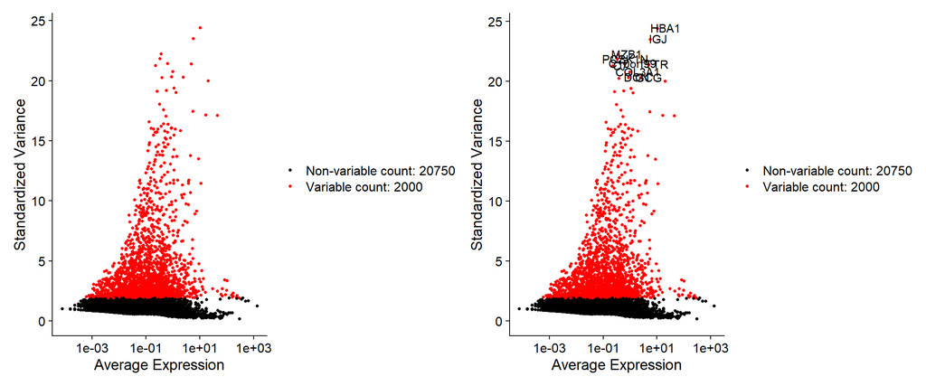

```r
# Scatter plot of average expression and standardized variance
## each dot is a gene

top10_list <- head(VariableFeatures(merged_ob), 10)
p1 <- VariableFeaturePlot(merged_ob)
p2 <- LabelPoints(plot = p1, points = top10_list)

p1 + p2
```

## Check Cell Cycle Batch

Cell cycle can affect the results, so we need to do QC on it. We will be looking at the G1, S, and G2/M phases.

For human, you can find a curated list of cell cycle genes in Seurat with the code below. For mouse, you will have to find or make a cell cycle gene list.

```r
# human cc genes found in Seurat
## might not find all of these genes in dataset (might give warning about that)
cc_genes <- cc.genes.updated.2019
```

To check cell cycle QC, we can run the code below:

```r
# calculate scores
# ?CellCycleScoring
merged_ob <- CellCycleScoring(merged_ob, s.features = cc_genes$s.genes, g2m.features = cc_genes$g2m.genes, set.ident = TRUE)
# scale data on cc genes
merged_ob <- ScaleData(merged_ob, features = c(cc_genes$s.genes, cc_genes$g2m.genes), verbose = F)

# run PCA on cc genes
merged_ob <- RunPCA(merged_ob, features = c(cc_genes$s.genes, cc_genes$g2m.genes),
                    nfeatures.print = 5, reduction.name = 'cc_pca', verbose = F)
```

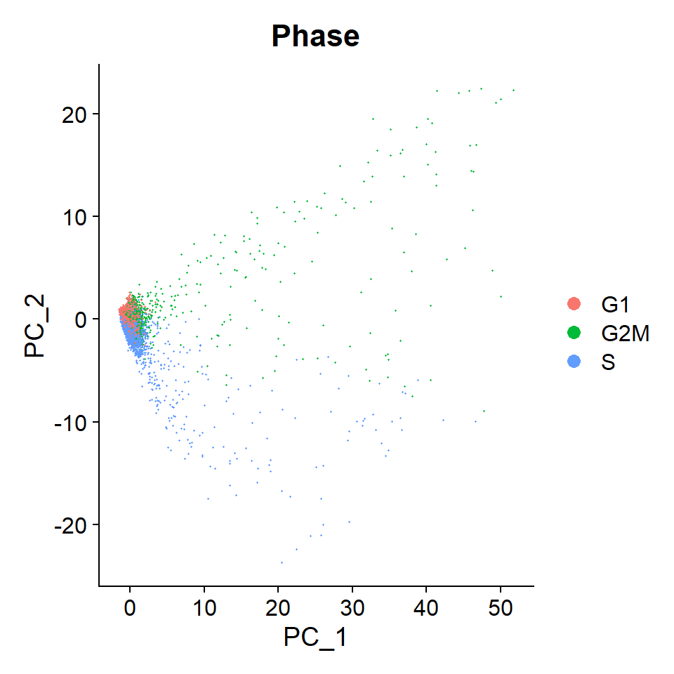

```r
# plot PCA of cc phases
DimPlot(merged_ob, reduction = 'cc_pca', group.by = 'Phase')
```

If you decide to correct for cell cycle, we can check how it’s corrected with the codes below:

- Method 1: Regress out all cell cycle effects

```r
# scale on cc genes and regress on the S and G2/M scores
merged_ob <- ScaleData(merged_ob, features = c(cc_genes$s.genes, cc_genes$g2m.genes),
                   vars.to.regress = c('S.Score', 'G2M.Score'), verbose = F)

# run PCA on fully regressed cc genes
merged_ob <- RunPCA(object = merged_ob, features = c(cc_genes$s.genes, cc_genes$g2m.genes),
                    nfeatures.print = 5, reduction.name = 'cc_pca', verbose = F)
```

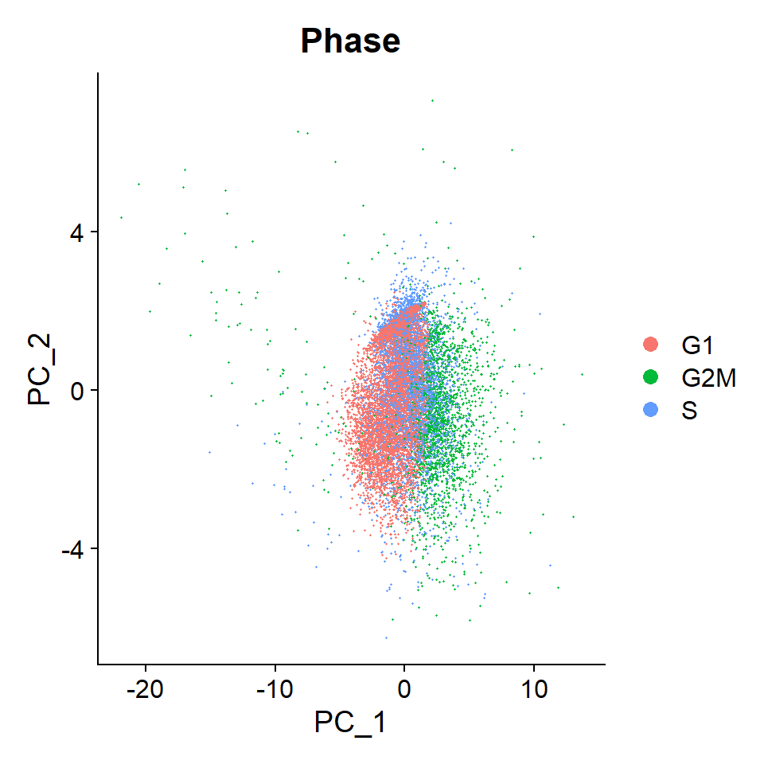

```r
# plot PCA of cc phases
DimPlot(merged_ob, reduction = 'cc_pca', group.by = 'Phase')
```

- Method 2: Regress out some cell cycle effects

```r
# will only see differences between non-cycling (G1) and cycling cells (S and G2/M)

# subtract S and G2/M scores
merged_ob$CC.Difference <- merged_ob$S.Score - merged_ob$G2M.Score

# scale on cc genes regressing out difference between S and G2/M phases
merged_ob <- ScaleData(merged_ob, features = c(cc_genes$s.genes, cc_genes$g2m.genes),
                   vars.to.regress = c("CC.Difference"), verbose = F)

# run PCA on regressed cc genes
merged_ob <- RunPCA(object = merged_ob, features = c(cc_genes$s.genes, cc_genes$g2m.genes),
                    nfeatures.print = 5, reduction.name = 'cc_pca', verbose = F)
```

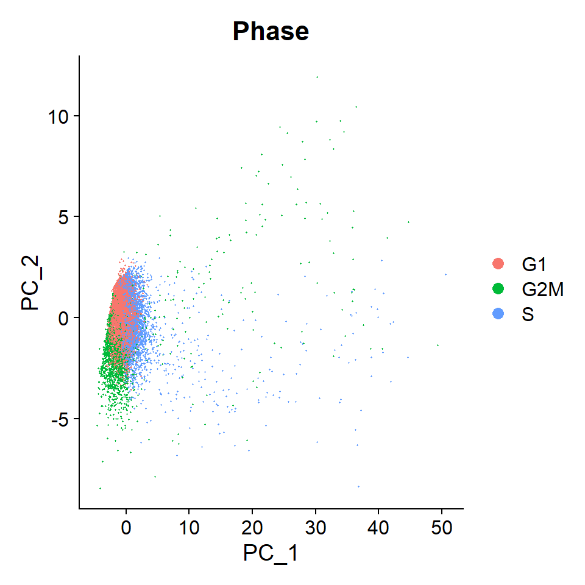

```r
# plot PCA of cc phases
DimPlot(merged_ob, reduction = 'cc_pca', group.by = 'Phase')
```

## Scaling

Scaling changes the range of values (not the distribution like normalization does). The values are centered around a mean with a unit standard deviation. Scaling helps to reduce unwanted variation and is required to run PCA in Seurat (otherwise you will get an error).

We will use this function:

```r
# scale data
# ?ScaleData
merged_ob <- ScaleData(merged_ob, vars.to.regress = 'nCount_RNA')
```

We will regress on *nCount* to reduce variation from library preparation among cells. You can add more variables like *percent.mt* if you decide to. You don’t even have to regress on any variable if you don’t need it.

We will only scale on the top 2000 variable genes because it will make the processing go a lot faster, and we will not be using the Seurat plot functions that require scaled data. Remember that we won’t be able to find genes outside of the top 2000 variable genes list. Ultimately, we will only be using the variable genes to get good clustering and UMAPs.

```r
# genes x cells of scaled data
dim(merged_ob@assays$RNA@scale.data)
```

```
## [1]  2000 13082
```

```r
# Is HBA1 in scaled data?
'HBA1' %in% rownames(merged_ob@assays$RNA@scale.data)
```

```
## [1] TRUE
```

```r
# Is CD4 in scaled data?
'CD4' %in% rownames(merged_ob@assays$RNA@scale.data)
```

```
## [1] FALSE
```

## Linear Dimension Reduction: PCA

PCA helps to reduce the dimension of the dataset or # of variables used for downstream analyses. In scRNA-seq, dimensions are genes.

We will use this function:

```r
# run PCA
# ?RunPCA
merged_ob <- RunPCA(merged_ob, features = VariableFeatures(merged_ob),  nfeatures.print = 5)
```

```
## PC_ 1
## Positive:  KRT19, FXYD3, C19orf33, TSPAN1, AGR2
## Negative:  CPB1, CELA3B, CELA2A, PLA2G1B, CTRC
## PC_ 2
## Positive:  LYZ, RP11-462G2.1, CLDN18, FXYD3, CEACAM6
## Negative:  SPARCL1, IGFBP7, CALD1, TIMP3, COX7A1
## PC_ 3
## Positive:  HLA-DRA, HLA-DPA1, CTSB, CD68, C1QC
## Negative:  PRSS3, KLK1, AMY2B, CPA2, CEL
## PC_ 4
## Positive:  PLVAP, CLEC14A, SLCO2A1, CLDN5, ELTD1
## Negative:  TAGLN, ACTA2, MYH11, RERGL, FRZB
## PC_ 5
## Positive:  CEACAM5, CEACAM6, CLDN18, A2M, MUC20
## Negative:  SERPINA5, SLC4A4, FXYD2, AMBP, LEFTY1
```

We will run on the top 2000 variable genes, which is the default in Seurat.

To choose how many PCs to use in downstream analyses, we will look at the PCA in two ways:

- Qualitative method

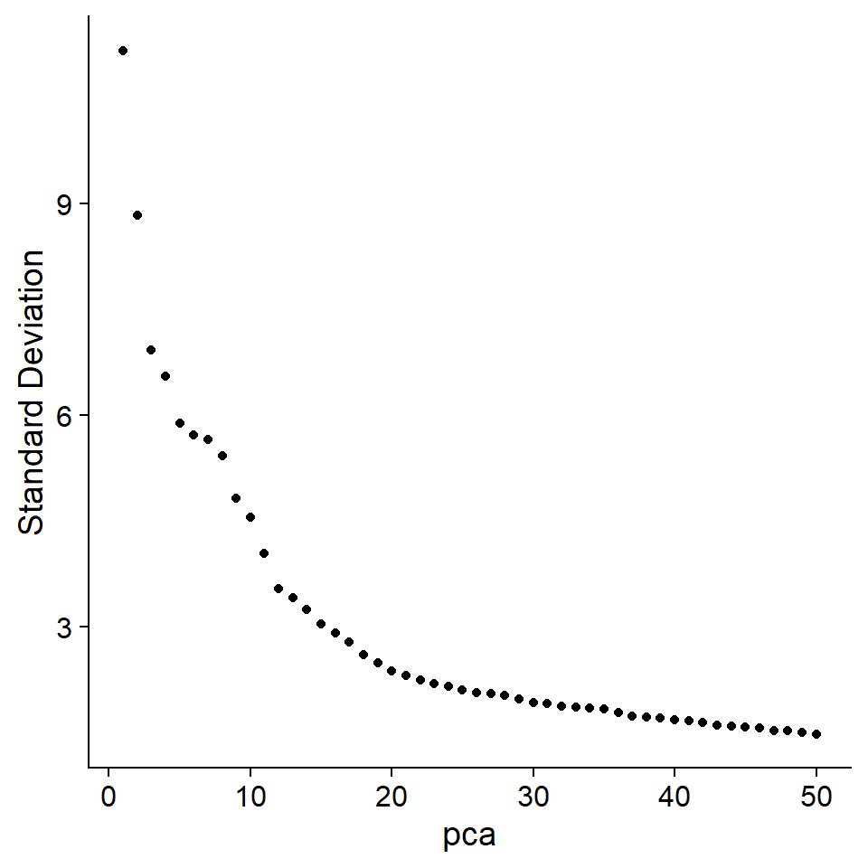

```r
# scree/elbow plot
# ?ElbowPlot
ElbowPlot(merged_ob, ndims = 50)
```

We will not do a JackStraw plot because it takes a long time to run (and I don’t normally use it). However, here is the code for it:

```r
# JackStraw plot
## DO NOT RUN
# merged_ob <- JackStraw(merged_ob)
# merged_ob <- ScoreJackStraw(merged_ob, dims = 1:20)
# JackStrawPlot(merged_ob, dims = 1:20)
```

- Quantitative method

```r
# complex method - make range of PCs for high threshold
## will choose minimum value of this range
pct <- merged_ob@reductions$pca@stdev / sum(merged_ob@reductions$pca@stdev) * 100
cum <- cumsum(pct)
co1 <- which(cum > 90 & pct < 5)[1]
co2 <- sort(which((pct[1:length(pct)-1] - pct[2:length(pct)]) > .1), decreasing = T)[1] + 1
pcs <- min(co1, co2)

# will use 1-18 PCs for downstream analyses
```

This is also a good place to check for potential batch effects.

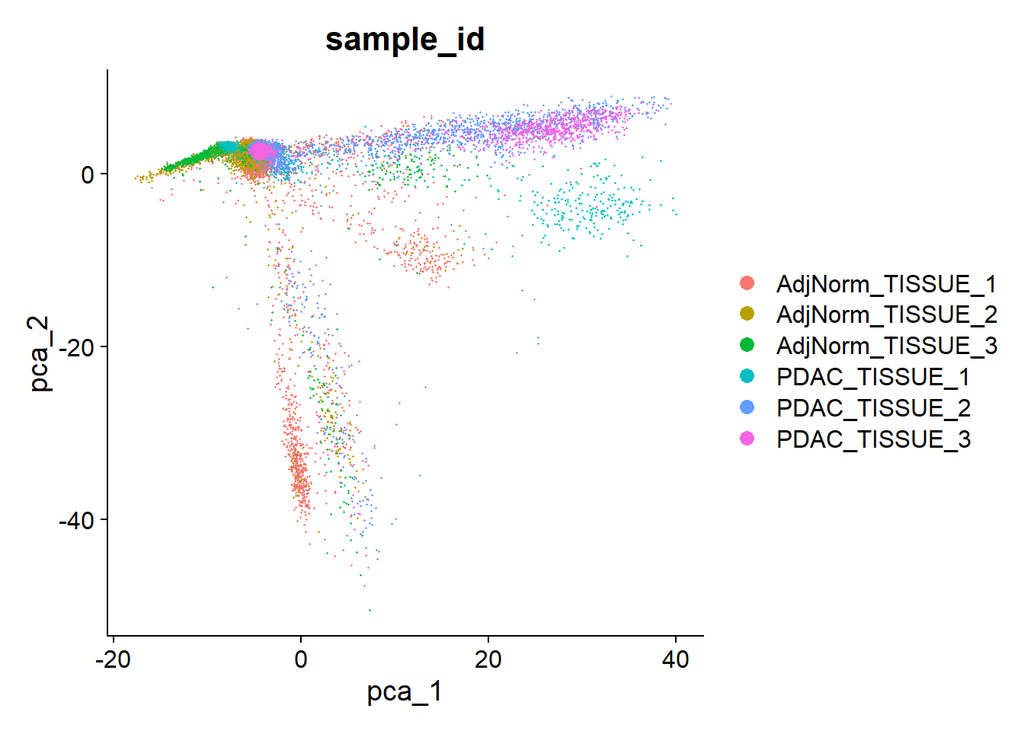

```r
# PCA plot (with sample_id)
DimPlot(merged_ob, reduction = 'pca', group.by = 'sample_id')
```

## Clustering

Clustering is an unsupervised technique. It divides data points into groups with similar traits and assigns them as clusters. In scRNA-seq, data points are cells. Seurat uses a graph-based method, and it does it in two steps:

1. Find neighbors using KNN graph
2. Find clusters using Louvain algorithm

We will use the code below:

```r
# find neighbors
# ?FindNeighbors
## pcs = 18
merged_ob <- FindNeighbors(merged_ob, dims = 1:pcs, k.param = 20)
# find clusters
# ?FindClusters
merged_ob <- FindClusters(merged_ob)
```

```
## Modularity Optimizer version 1.3.0 by Ludo Waltman and Nees Jan van Eck
##
## Number of nodes: 13082
## Number of edges: 457331
##
## Running Louvain algorithm...
## Maximum modularity in 10 random starts: 0.9423
## Number of communities: 30
## Elapsed time: 1 seconds
```

We will use the PCA results from above when clustering, which is the default in Seurat. We will also use a resolution 0.8, which is the default in Seurat. To increase the # of clusters, you can increase the resolution.

```r
# look at how many clusters we get
head(Idents(merged_ob), 5)
```

```
## AdjNorm_TISSUE_1_AAACCCAGTCCGACGT-1 AdjNorm_TISSUE_1_AAACCCAGTGTCGCTG-1
##                                  11                                  27
## AdjNorm_TISSUE_1_AAACCCATCTGCACCT-1 AdjNorm_TISSUE_1_AAACGAAAGCGACCCT-1
##                                  16                                   1
## AdjNorm_TISSUE_1_AAACGAAAGCGGACAT-1
##                                   0
## 30 Levels: 0 1 2 3 4 5 6 7 8 9 10 11 12 13 14 15 16 17 18 19 20 21 22 23 ... 29
```

```r
# store clusters in metadata slot
merged_ob$clusters <- Idents(merged_ob)
```

## Non-Linear Dimension Reduction - UMAP

Non-linear dimension reduction methods learn the underlying manifold of the data to place similar cells together in a low-dimensional space. The main methods used in scRNA-seq are tSNE and UMAP. We will be using UMAP for this example. For both methods, we will use the PCs to speed up processing.

If you want to run tSNE, the code is below:

```r
## DO NOT RUN
# ?RunTSNE
# merged_ob <- RunTSNE(merged_ob, dims = 1:pcs)
```

Code to run UMAP is below:

```r
# run UMAP
# ?RunUMAP
merged_ob <- RunUMAP(merged_ob, dims = 1:pcs)
```

There are many ways to customize your UMAPs with the DimPlot function. The parameters I have shown are not all of them, but there are some parameters for changing colors, point size, etc.

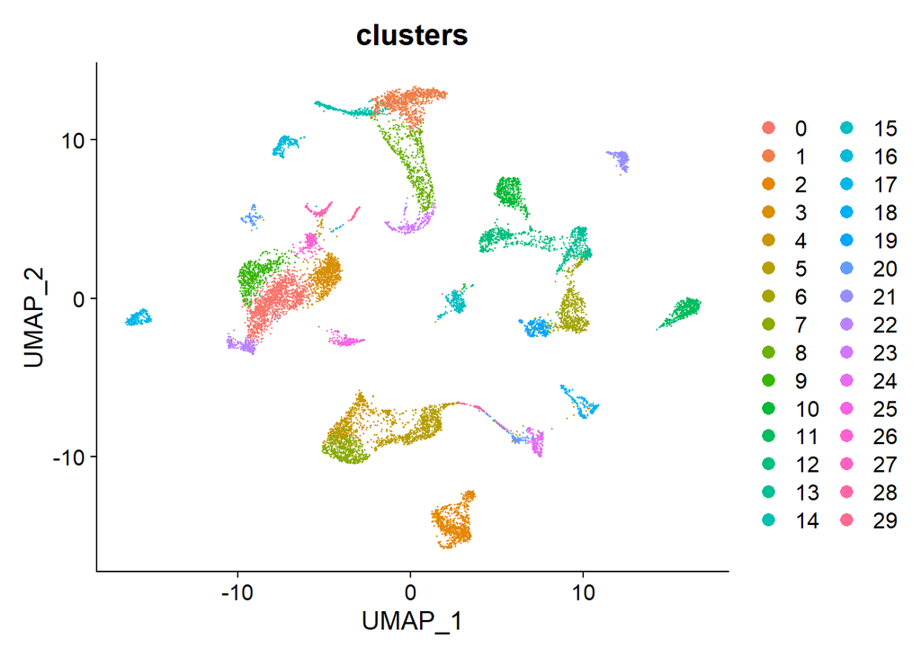

```r
# plot UMAP (with cluster #s)
# ?DimPlot
DimPlot(merged_ob, group.by = 'clusters')
```

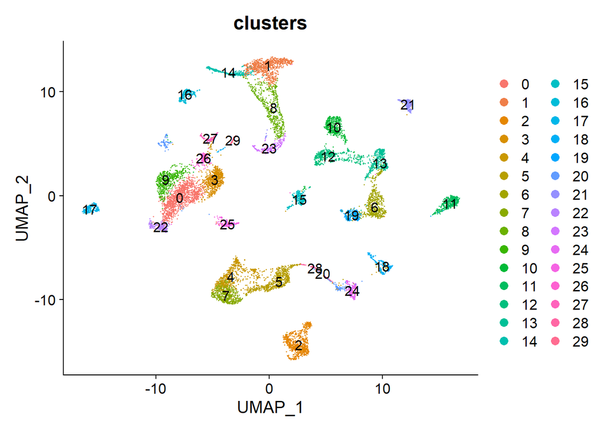

```r
# plot UMAP (with cluster #s and labeled)
DimPlot(merged_ob, group.by = 'clusters', label = T)
```

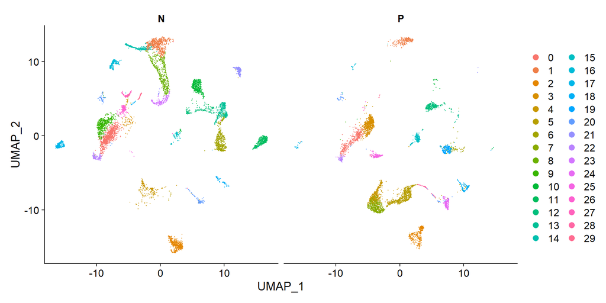

```r
# plot UMAP (with cluster #s and split into different plots by condition)
DimPlot(merged_ob, split.by = 'condition')
```

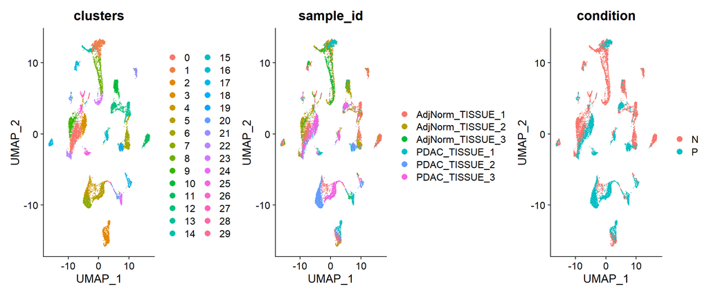

```r
# plot different UMAP (with cluster #s, sample ID, and condition)
DimPlot(merged_ob, group.by = c('clusters', 'sample_id', 'condition'))
```

From these UMAPs plotted by ‘clusters’, ‘sample_id’, and ‘condition’, we can see that there are potential batch effect variables. We will choose ‘sample_id’ as the main batch effect variable. We could have chosen ‘condition’, but ‘sample_id’ also takes into account ‘condition’. We will use this batch variable in the integration pipeline.

## Save Object (Unbatched)

```r
# save processed object (ignoring batch effect)
saveRDS(merged_ob, 'pasca_unbatched_umap.rds')
```

## DE

DE is where you can run comparison tests. The examples shown below do not account for batch effect.

### Finding DE genes for clusters

By doing DE on clusters, we can see what genes makes each cluster different from each other. When we are testing, we are comparing one cluster to the rest of the cells (ignoring cluster).

We can use the function below to do this:

```r
# ?FindMarkers
de_unbatch_0 <- FindMarkers(merged_ob, ident.1 = 0)

head(de_unbatch_0)
```

```
##       p_val avg_log2FC pct.1 pct.2 p_val_adj
## RUNX3     0   1.523105 0.659 0.143         0
## CD52      0   1.298735 0.873 0.309         0
## LCK       0   1.290523 0.618 0.132         0
## CD2       0   2.191710 0.880 0.150         0
## RPS27     0   1.354173 0.999 0.897         0
## CD247     0   1.075670 0.617 0.122         0
```

We can run through all the clusters easily with this function:

```r
# ?FindAllMarkers
## DO NOT RUN
# de <- FindAllMarkers(merged_ob)

# save DE table
## DO NOT RUN
# write_csv(de, 'tables/cds_pasca_unbatched_de.csv')
```

Instead of running all the clusters right now, I have run it for you because it can take a long time. You can load in the full DE table with the code below:

```r
de <- read_csv('D:/scRNA-seq pipeline/pasca_dataset/tables/cds_pasca_unbatched_de.csv')
```

Here are descriptions of the columns in the DE table:

- **p_val** = p-value (not adjusted)
- **avg_log2FC** = log2 fold-change (FC) of average expression between 2 groups
  - log2(FC1) - log2(FC2)
  - Positive (+) value = higher in group 1
  - Negative (-) value = lower in group 1
- **pct.1/pct.2** = % of cells where gene is expressed in group (1 or 2)
  - expressed = normalized expression > 0
- **p_val_adj** = adjusted p-value
  - by Bonferroni
- **cluster** = name of group compared
  - this is group 1
- **gene** = name of gene

To find the most important DE genes, we can do the code below:

```r
# filter by adjusted p-value < .05
## make sure you are looking at significant genes
de_filt <- de %>% dplyr::filter(p_val_adj < .05)

# sort by average log2FC (most positive to most negative)
de_filt <- de_filt %>% arrange(-avg_log2FC)

# can condense code and write as:
## DO NOT RUN
# de_filt <- de %>% dplyr::filter(p_val_adj < .05) %>% arrange(cluster, -avg_log2FC)
```

### Finding DE genes between groups

To find DE genes between groups, it’s very similar to finding for clusters.

```r
# run DE for N vs. P condition
de_condition <- FindMarkers(merged_ob, ident.1 = 'N', ident.2 = 'P', group.by = 'condition')
de_condition_filt <- de_condition %>% rownames_to_column('gene') %>% dplyr::filter(p_val_adj < .05) %>% arrange(-avg_log2FC)

head(de_condition_filt)
```

```
##       gene         p_val avg_log2FC pct.1 pct.2    p_val_adj
## 1      HBB  0.000000e+00   6.594310 0.256 0.005  0.00000e+00
## 2     HBA2 1.876523e-115   5.347997 0.114 0.009 4.26909e-111
## 3      INS 7.322592e-211   3.777440 0.173 0.003 1.66589e-206
## 4   CELA2A  0.000000e+00   3.213982 0.598 0.049  0.00000e+00
## 5    CTRB2  0.000000e+00   3.143994 0.608 0.049  0.00000e+00
## 6 C11orf96  4.881536e-51   2.796137 0.117 0.044  1.11055e-46
```

```r
# can also do this with FindAllMarkers function
## DO NOT RUN
## change active identity
# Idents(merged_ob) <- 'condition'
# ## run DE for N vs. P and P vs. N condition
# de_condition <- FindAllMarkers(merged_ob)
# de_condition_filt <- de_condition %>% dplyr::filter(p_val_adj < .05) %>% arrange(-avg_log2FC)
```